# Descriptive Analysis

PsyFaKo Open Science Survey

Johannes Brachem

Last update: 09 April, 2020

# 1 Header

## 1.1 Load Packages

```r
source("code/helpers/helper_functions.R")
```

## 1.2 Import Data

```r
wide <- read_csv("data/wide.csv") %>%
  only_psych() %>% filter(emp_experience == "Yes")
long <- read_csv("data/long.csv") %>%
  only_psych() %>% filter(emp_experience == "Yes")
wide_all <- read_csv("data/wide.csv") %>% only_psych()
stats <- readRDS("data/stats_software.rds")
```

# 2 Question Block 2: Research Practices

```r
n_projects_total <- long %>%
  distinct(id, n_projects) %>%
  summarise(n = sum(n_projects, na.rm = TRUE)) %>%
  pull(n)
```

## 2.1 Preregistered Analyses

**Note**: In our preregistration, we only specified analyses for questionable research practices. Because it might be of interest, we also calculate the same figures for the two open research practices that we asked about. One should be very careful to compare both types of practices here directly, because the number of questionable research practices that we asked about was a lot higher (9), than the number of open practices that we asked about (2). So, e.g. a difference of 1.3 questionable practices applied per project on average, compared to only 0.5 open practices is almost certainly confounded by the number of specific practices that were assessed.

### 2.1.1 Full Aggregation

#### 2.1.1.1 Mean Number of QRPs and ORPs applied per Project per Participant

The chunk below first sums up, how many QRPs and ORPs were totally applied by each participant. Then, theses sums are each divided by the total number of projects conducted by each participant, returning the average number of QRPs / ORPs applied per project.

```r
# Mean over individual scores: Number of RP applications per project,
# averaged across individuals (preregistered)

q01 <- long %>%
  # number of applied practices (per individual and type of project)
  group_by(id, type_of_practice, n_projects) %>%
  summarise(applied_practices = sum(rp_applied, na.rm = TRUE)) %>%
  ungroup() %>%
  mutate(practices_per_project = applied_practices / n_projects) %>%

  # average over individuals
  group_by(type_of_practice) %>%
  summarise(m = mean(practices_per_project),
            sd = sd(practices_per_project),
            med = median(practices_per_project),
            minimum = min(practices_per_project),
            maximum = max(practices_per_project))

q01
```

```
## # A tibble: 2 x 6
##   type_of_practice     m    sd   med minimum maximum
##   <chr>            <dbl> <dbl> <dbl>   <dbl>   <dbl>
## 1 Open             0.595 0.611   0.5       0       2
## 2 Questionable     1.26  1.40    1         0       9
```

```r
# changed, 05.03.2020: Because we can not be sure, if the answers to "project" and "other refer to single projects or mutiple projects, we calculate a second number which excludes these projects from the calculation.

q01.reduced <- long %>%
  filter(project %in% c('emp.intern', 'thesis.bsc', 'thesis.msc')) %>%
  # number of applied practices (per individual and type of project)
  group_by(id, type_of_practice, n_projects) %>%
  summarise(applied_practices = sum(rp_applied, na.rm = TRUE)) %>%
  ungroup() %>%
  mutate(practices_per_project = applied_practices / n_projects) %>%

  # average over individuals
  group_by(type_of_practice) %>%
  summarise(m = mean(practices_per_project),
            sd = sd(practices_per_project),
            med = median(practices_per_project),
            minimum = min(practices_per_project),
            maximum = max(practices_per_project))

q01.reduced
```

```
## # A tibble: 2 x 6
##   type_of_practice     m    sd   med minimum maximum
##   <chr>            <dbl> <dbl> <dbl>   <dbl>   <dbl>
## 1 Open             0.498 0.572 0.333       0       2
## 2 Questionable     0.994 1.25  0.667       0       9
```

### 2.1.2 Project Aggregation

How many open/questionable research practices were applied on average per project?

```r
q02 <- long %>%
  group_by(id, type_of_practice, project, project_conducted) %>%
  summarise(n_practice_appl = sum(rp_applied)) %>%
  ungroup() %>%
  group_by(type_of_practice, project) %>%
  summarise(mean = mean(n_practice_appl, na.rm = TRUE), # mean number of applied practices per project
            sd = sd(n_practice_appl, na.rm = TRUE), # sd for number of applied practices per project
            n_conducted = sum(project_conducted), # number of conducted projects
            n_applied = sum(n_practice_appl, na.rm=TRUE), # number of practice applications
            med = median(n_practice_appl, na.rm = T),
            minimum = min(n_practice_appl, na.rm = T),
            maximum = max(n_practice_appl, na.rm = T))

q02
```

```
## # A tibble: 10 x 9
## # Groups:   type_of_practice [2]
##    type_of_practice project  mean    sd n_conducted n_applied   med minimum
##    <chr>            <chr>   <dbl> <dbl>       <int>     <int> <dbl>   <int>
##  1 Open             emp.in… 0.656 0.739        1100       711     0       0
##  2 Open             other   0.404 0.661         280       112     0       0
##  3 Open             project 0.423 0.635         459       192     0       0
##  4 Open             thesis… 0.534 0.660         629       332     0       0
##  5 Open             thesis… 0.709 0.771         153       107     1       0
##  6 Questionable     emp.in… 1.42  1.63         1100      1497     1       0
##  7 Questionable     other   0.825 1.35          280       222     0       0
##  8 Questionable     project 1.30  1.52          459       582     1       0
##  9 Questionable     thesis… 1.03  1.34          629       634     1       0
## 10 Questionable     thesis… 0.503 0.851         153        75     0       0
## # … with 1 more variable: maximum <int>
```

### 2.1.3 Practice Aggregation

For every practice, we compute the share of participants who applied that practice *at least one* in any project. We only include participants who have conducted at least one empirical research project.

```r
q03 <- long %>%
  filter(rp_applied) %>%
  group_by(practice, type_of_practice) %>%
  summarise(n = n_distinct(id)) %>%
  mutate(n_vp = nrow(wide)) %>%
  mutate(share = (n / n_vp)*100) %>%
  arrange(share %>% desc()) %>%
  identity()

# print
q03
```

```
## # A tibble: 11 x 5
## # Groups:   practice [11]
##    practice             type_of_practice     n  n_vp share
##    <chr>                <chr>            <int> <int> <dbl>
##  1 Power Analysis       Open               592  1146 51.7
##  2 No Sample Planning   Questionable       561  1146 49.0
##  3 Preregistration      Open               432  1146 37.7
##  4 SR of Variables      Questionable       417  1146 36.4
##  5 Flexible Analysis    Questionable       292  1146 25.5
##  6 Flexible Exclusion   Questionable       257  1146 22.4
##  7 SR of Conditions     Questionable       195  1146 17.0
##  8 SR of Hypotheses     Questionable       174  1146 15.2
##  9 HARKing              Questionable       141  1146 12.3
## 10 Flexible Sample Size Questionable       131  1146 11.4
## 11 Rounding p-Values    Questionable        39  1146  3.40
```

### 2.1.4 Detailed Practice Aggregation

```r
q04.n_projects <- long %>%
  ungroup() %>%
  distinct(id, project, project_conducted) %>%
  group_by(project) %>%
  summarise(n = sum(project_conducted)) %>%
  mutate(order = c(1, 5, 2, 3, 4)) %>%
  arrange(order) %>%
  arrange(project)

q04.d <- long %>% arrange(project) %>%
  mutate(q04.n = rep(q04.n_projects$n, each = nrow(long) / 5))

q04 <- q04.d %>%
  ungroup() %>%
  group_by(practice, type_of_practice, project, q04.n) %>%
  # group_by(practice) %>%
  summarise(n = sum(rp_applied, na.rm = TRUE)) %>% ungroup() %>%
  # group_by(practice, type_of_practice, project, q04.n) %>%
  mutate(share = (n / q04.n)*100) %>%
  arrange(type_of_practice) %>%
  identity()

# print
q04 %>% print(n = nrow(.))
```

```
## # A tibble: 55 x 6
##    practice             type_of_practice project    q04.n     n share
##    <chr>                <chr>            <chr>      <int> <int> <dbl>
##  1 Power Analysis       Open             emp.intern  1100   430 39.1
##  2 Power Analysis       Open             other        280    65 23.2
##  3 Power Analysis       Open             project      459   110 24.0
##  4 Power Analysis       Open             thesis.bsc   629   210 33.4
##  5 Power Analysis       Open             thesis.msc   153    66 43.1
##  6 Preregistration      Open             emp.intern  1100   286 26
##  7 Preregistration      Open             other        280    49 17.5
##  8 Preregistration      Open             project      459    86 18.7
##  9 Preregistration      Open             thesis.bsc   629   125 19.9
## 10 Preregistration      Open             thesis.msc   153    43 28.1
## 11 Flexible Analysis    Questionable     emp.intern  1100   180 16.4
## 12 Flexible Analysis    Questionable     other        280    28 10
```

[output cut: 43 more lines]

## 2.2 Platforms for Preregistration

`prereg_where` contains the answers to the question “Which platform did you use for your preregistration?”. Multiple answers where possible. They are coded:

| answer | meaning |
| --- | --- |
| 1 | preregistration given to lecturer |
| 2 | aspredicted.org |
| 3 | osf.io |
| 4 | journal |
| 5 | other |
| 6 | I never preregistered |

```r
prereg_where <- wide %>%
  pull(prereg_where)

prereg_counts <- as.character(1:6) %>%
  map_dbl(function(x) prereg_where %>% str_count(x) %>% sum(na.rm=T))

names_prereg_where <- c("lecturer", "aspredicted.org", "osf.io",
                        "journal", "other", "never preregistered")

prereg_where_data <- tibble(names_prereg_where, prereg_counts) %>%
  mutate(share = prereg_counts / nrow(wide))
```

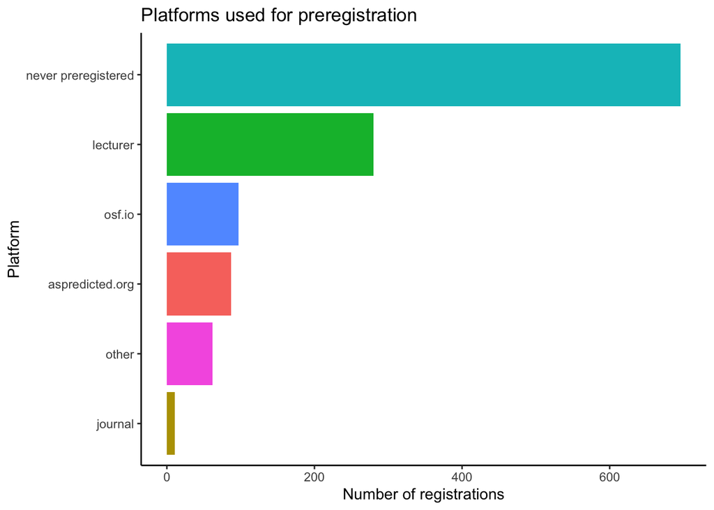

```r
prereg_where_data %>%
  ggplot(aes(x = fct_reorder(names_prereg_where,
                             prereg_counts),
             y = prereg_counts)) +
  geom_bar(stat = "identity", aes(fill = names_prereg_where)) +
  labs(x = "Platform", y = "Number of registrations",
       title = "Platforms used for preregistration",
       fill = "Platform") +
  coord_flip() +
  theme_classic() +
  theme(legend.position = "none") +
  # theme_fivethirtyeight() +
  # ggthemes::theme_solarized() +
  NULL
```

## 2.3 Non-registered Analyses

### 2.3.1 Share of practice applications

For each practice, we look at the share of projects in which the respective practice was applied.

```r
n_proj <- long %>% distinct(id, project, project_conducted) %>%
  summarise(n = sum(project_conducted)) %>% pull(n)

q05 <- long %>%
  # filter(project %contains% "thesis.bsc" | project %contains% "thesis.msc") %>%
  filter(rp_applied) %>%
  group_by(practice, type_of_practice) %>%
  summarise(n_applied = n()) %>%
  mutate(n_projects = n_proj) %>%
  mutate(share = (n_applied / n_projects)*100) %>%
  arrange(share %>% desc())

q05
```

```
## # A tibble: 11 x 5
## # Groups:   practice [11]
##    practice             type_of_practice n_applied n_projects share
##    <chr>                <chr>                <int>      <int> <dbl>
##  1 No Sample Planning   Questionable           897       2621 34.2
##  2 Power Analysis       Open                   881       2621 33.6
##  3 SR of Variables      Questionable           606       2621 23.1
##  4 Preregistration      Open                   589       2621 22.5
##  5 Flexible Analysis    Questionable           417       2621 15.9
##  6 Flexible Exclusion   Questionable           335       2621 12.8
##  7 SR of Conditions     Questionable           258       2621  9.84
##  8 SR of Hypotheses     Questionable           229       2621  8.74
##  9 Flexible Sample Size Questionable           167       2621  6.37
## 10 HARKing              Questionable           162       2621  6.18
## 11 Rounding p-Values    Questionable            50       2621  1.91
```

### 2.3.2 Open Science Initiatives

```r
nosi_q <- long %>%
  # number of applied practices (per individual and type of project)
  group_by(id, type_of_practice, n_projects, nosi_at_uni) %>%
  summarise(applied_practices = sum(rp_applied, na.rm = TRUE)) %>%
  ungroup() %>%
  mutate(practices_per_project = applied_practices / n_projects)

  # average over individuals
nosi_q %>%
  group_by(type_of_practice, nosi_at_uni) %>%
  summarise(m = mean(practices_per_project),
            sd = sd(practices_per_project))
```

```
## # A tibble: 4 x 4
## # Groups:   type_of_practice [2]
##   type_of_practice nosi_at_uni     m    sd
##   <chr>            <chr>       <dbl> <dbl>
## 1 Open             No          0.508 0.555
## 2 Open             Yes         0.877 0.693
## 3 Questionable     No          1.31  1.43
## 4 Questionable     Yes         1.11  1.27
```

# 3 Save Results

```r
block2 <- list(q01 = q01,
               q01.reduced = q01.reduced,
                    q02 = q02,
                    q03 = q03,
                    q04 = q04,
                    q05 = q05,
               prereg_data = prereg_where_data)

saveRDS(block2, "data/block2_results.rds")
```

# 4 Question Block 3: Teaching Coverage, Attitudes

```r
# global
n_participants <- nrow(wide_all)
```

## 4.1 Specific QRPs in teaching

Which of these research practices have been talked about in a critical way in the course of your studies?

```r
q_qrp_t.spec <- wide_all %>%
  mutate(id = 1:nrow(.)) %>%
  select(id, study_stage_mc, semester, specific_qrps_teaching) %>%
  separate(specific_qrps_teaching, into = paste0("qrp.t", 1:11)) %>%
  gather(qrp.t1:qrp.t11, key = "answer_number", value = "qrp_id") %>%
  drop_na(qrp_id) %>%
  mutate(qrp = dplyr::recode(qrp_id,
                             "1" = "SR of Variables",
                             "2" =    "No Sample Planning",
                             "3" =     "Flexible Sample Size",
                             "4" =    "SR of Conditions",
                             "5" =   "Flexible Analysis",
                             "6" =    "Flexible Exclusion",
                             "7" =    "SR of Hypotheses",
                             "8" =   "HARKing",
                             "9" =    "Rounding p-Values",
                             "10" =   "None",
                             "11" =   "Not Sure")) %>%
  select(-answer_number, -qrp_id)
q_qrp_t.spec_share <- q_qrp_t.spec %>%
  group_by(qrp) %>% summarise(n = n()) %>% ungroup() %>%
  mutate(share = n / n_participants * 100) %>% arrange(share %>% desc())
```

## 4.2 Replication Crisis in any lecture

Did you hear about the replication crisis in a lecture?

```r
rc_teaching_general <- wide_all %>%
  # summarise semesters into year-chunks,
  # filter(study_stage_mc != "Other") %>%
  mutate(semester = ifelse(semester %% 2 == 0, semester - 1, semester)) %>%
  mutate(semester = ifelse(semester > 10, 11, semester)) %>%
  mutate(semester = ifelse(is.na(semester), "not applicable", semester)) %>%
  mutate(semester = factor(semester, levels = c(1, 3, 5, 7, 9, 11, "not applicable"),
                           labels = c("1/2", "3/4", "5/6",
                                      "7/8", "9/10", ">10", "not applicable"))) %>%

  # select relevant variables and summarise
  select(rc_teaching, semester, study_stage_mc) %>%
  group_by(rc_teaching, semester, study_stage_mc) %>%
  summarise(n = n()) %>%
  ungroup() %>%

  # number of participants per semester and study stage
  group_by(semester, study_stage_mc) %>%
  mutate(n_semester = sum(n)) %>%
  ungroup() %>%

  # share with respect to students in the same study stage and semester
  mutate(share = (n / n_semester) * 100)

# print
rc_teaching_general %>%
  arrange(study_stage_mc) %>%
  print(n = nrow(.))
```

```
## # A tibble: 39 x 6
##    rc_teaching semester      study_stage_mc             n n_semester  share
##    <chr>       <fct>         <chr>                  <int>      <int>  <dbl>
##  1 no          1/2           Bachelor                  64        206  31.1
##  2 no          3/4           Bachelor                  52        321  16.2
##  3 no          5/6           Bachelor                  39        268  14.6
##  4 no          7/8           Bachelor                  19         87  21.8
##  5 no          9/10          Bachelor                   2          6  33.3
##  6 no          >10           Bachelor                   1          2  50
##  7 unsure      1/2           Bachelor                  18        206   8.74
##  8 unsure      3/4           Bachelor                  14        321   4.36
##  9 unsure      5/6           Bachelor                  10        268   3.73
## 10 unsure      7/8           Bachelor                   1         87   1.15
## 11 yes         1/2           Bachelor                 124        206  60.2
## 12 yes         3/4           Bachelor                 255        321  79.4
```

[output cut: 27 more lines]

Replication crisis in lectures by university

```r
rc_teaching_unis <- wide_all %>%
  group_by(uni_current) %>% mutate(n_uni = n()) %>% ungroup() %>%
  group_by(uni_current, rc_teaching) %>%
  mutate(n = n()) %>% ungroup() %>%
  mutate(share = n / n_uni) %>%
  distinct(uni_current, n_uni, rc_teaching, n, share) %>% arrange(uni_current)

rc_teaching_unis %>%
  mutate(share = (share*100) %>% round(1),
         share = paste0("(", share, " %)")) %>%
  unite(n, share, col = "n", sep = " ") %>%
  spread(key = rc_teaching, value = n, fill = "0 (0 %)")
```

```
## # A tibble: 47 x 5
##    uni_current n_uni no          unsure    yes
##    <chr>       <int> <chr>       <chr>     <chr>
##  1 1               4 1 (25 %)    0 (0 %)   3 (75 %)
##  2 10              2 0 (0 %)     0 (0 %)   2 (100 %)
##  3 11              3 2 (66.7 %)  0 (0 %)   1 (33.3 %)
##  4 12              3 0 (0 %)     0 (0 %)   3 (100 %)
##  5 13             20 5 (25 %)    2 (10 %)  13 (65 %)
##  6 15              9 3 (33.3 %)  0 (0 %)   6 (66.7 %)
##  7 16              1 1 (100 %)   0 (0 %)   0 (0 %)
##  8 17             18 8 (44.4 %)  1 (5.6 %) 9 (50 %)
##  9 18             23 13 (56.5 %) 3 (13 %)  7 (30.4 %)
## 10 19              4 1 (25 %)    0 (0 %)   3 (75 %)
## # … with 37 more rows
```

```r
rc_teaching_unis.out <- rc_teaching_unis %>%
  mutate(rc_teaching = factor(rc_teaching, levels = lab.rc_lectures,
                              labels = c("yes", "no", "not_sure"))) %>%
  unite(n, share, col = "n_share", sep = "_") %>%
  spread(key = rc_teaching, value = n_share, fill = "0_0") %>%
  separate(yes, into = c("yes.n", "yes.share"), sep = "_") %>%
  separate(no, into = c("no.n", "no.share"), sep = "_") %>%
  separate(not_sure, into = c("not_sure.n", "not_sure.share"), sep = "_") %>%
  arrange(desc(yes.share)) %>%
  filter(n_uni >= 30) %>%
  mutate_at(vars(matches("share")), as.numeric) %>%
  mutate_at(vars(matches("share")), cop2)
```

## 4.3 Replication Crisis in which lectures

In which lectures did you hear about the replication crisis?

```r
q_rc_t.spec <- wide_all %>%
  mutate(id = 1:nrow(.)) %>%
  separate(rc_teaching_specific, into = paste0("t", 1:11)) %>%
  select(id, study_stage_mc, semester, t1:t11) %>%
  gather(t1:t11, key = "answer_number", value = "lecture_id") %>%
  drop_na(lecture_id) %>%
  mutate(lecture = dplyr::recode(lecture_id,
                                 "1" = "General Psychology",
                                 "2" = "Work, Organizational and Economic Psychology",
                                 "3" = "Biological- / Neuropsychology",
                                 "4" = "Diagnostics",
                                 "5" = "Differential Psychology",
                                 "6" = "Introductory Class",
                                 "7" = "Developmental Psychology",
                                 "8" = "Health Psychology",
                                 "9" = "Clinical Psychology",
                                 "10" = "Media- / Communication Psychology",
                                 "11" = "Methods, Stats, Expra",
                                 "12" = "Pedagogical Psychology",
                                 "13" = "Forensic",
                                 "14" = "Social Psychology",
                                 "15" = "Other")) %>%
  select(-answer_number, -lecture_id)
q_rc_t.spec.share <- q_rc_t.spec %>%
  group_by(lecture) %>% summarise(n = n()) %>% ungroup() %>%
  mutate(share = n / n_participants * 100) %>% arrange(share %>% desc())
```

## 4.4 Attitudes towards replication crisis and open science

```r
# table of answers for the three questions
# 1: "not at all"
# 5: "very much"
wide_all %>%
  select(interest, importance, felt_information) %>%
  map(table)
```

```
## $interest
##
##   1   2   3   4   5
##  20  98 322 578 379
##
## $importance
##
##    1    2    3    4    5
##    5   17   59  283 1033
##
## $felt_information
##
##   1   2   3   4   5
## 101 376 447 366 107
```

# 5 Question Block 4: Other

## 5.1 Statistical Software

```r
# print
stats %>% print(n = nrow(.))
```

```
## # A tibble: 17 x 2
##    software       n
##    <chr>      <dbl>
##  1 SPSS        1033
##  2 R            678
##  3 Excel        224
##  4 MPlus         17
##  5 Statistica    11
##  6 SAS           10
##  7 JASP           8
##  8 Systat         4
##  9 Matlab         3
## 10 STATA          3
## 11 AMOS           2
## 12 G*Power        2
## 13 Jamovi         2
## 14 EQS            1
## 15 ER             1
## 16 HLM            1
## 17 PSPP           1
```

## 5.2 Open Science Initiatives

Do you know of an open science initiative at your university?

```r
# light wrangling
nosi_aggregation <- wide_all %>% select(nosi, uni_current, nosi_at_uni) %>%
  group_by(uni_current, nosi_at_uni, nosi) %>%
  summarise(n = n()) %>%
  ungroup() %>%
  mutate(nosi = factor(nosi, levels = c("No", "Not Sure", "Yes"))) %>%
  arrange(desc(nosi_at_uni))

# compute shares
nosi_agg2 <- nosi_aggregation %>%
  group_by(uni_current) %>%
  mutate(n_answers = sum(n)) %>%
  filter(nosi == "Yes") %>%
  mutate(share_yes = (n / n_answers) * 100) %>%
  select(uni_current, nosi_at_uni, n_answers, share_yes) %>%
  arrange(desc(share_yes))

# print
nosi_agg2
```

```
## # A tibble: 40 x 4
## # Groups:   uni_current [40]
##    uni_current                             nosi_at_uni n_answers share_yes
##    <chr>                                   <chr>           <int>     <dbl>
##  1 26                                      No                  1     100
##  2 27                                      No                  1     100
##  3 Georg-August-Universität Göttingen      Yes                54      83.3
##  4 19                                      No                  4      75
##  5 Universität Leipzig                     Yes                29      58.6
##  6 5                                       No                  7      57.1
##  7 Julius-Maximilians-Universität Würzburg No                 73      52.1
##  8 24                                      No                  4      50
##  9 9                                       No                  2      50
## 10 Ludwig-Maximilians-Universität München  Yes                55      49.1
## # … with 30 more rows
```

Have you heard of open science events (e.g. workshops or talks) at your university=

```r
nosi_events <- wide_all %>% select(nosi_events_mc) %>%
  group_by(nosi_events_mc) %>%
  summarise(n = n())

nosi_events
```

```
## # A tibble: 3 x 2
##   nosi_events_mc     n
##   <chr>          <int>
## 1 No               820
## 2 Not Sure         176
## 3 Yes              401
```

## 5.3 Block 3

```r
block3 <- list(qrps_teaching = q_qrp_t.spec,
               qrps_teaching_share = q_qrp_t.spec_share,
               rc_teaching_general = rc_teaching_general,
               rc_teaching_unis = rc_teaching_unis.out,
               rc_teaching_specific = q_rc_t.spec,
               rc_teaching_specific_share = q_rc_t.spec.share,
               nosi_data = nosi_agg2,
               nosi_events = nosi_events
               )

saveRDS(block3, "data/block3_results.rds")
```